# Uygulama - Çoklu Regresyon Analizi: Ek konular

Finansal Ekonometri (MPİ-TYL)

Prof. Dr. Hüseyin Taştan

Yıldız Teknik Üniversitesi

# 1 Standartlaştırılmış Regresyon

## 1.1 Örnek: Hava kirliliği ve ev fiyatları

Bu veri setinde `{wooldridge}` paketindeki `hprice2` veri setini kullanacağız.

```r
library(wooldridge)
data("hprice2")
str(hprice2)
```

```
## 'data.frame':    506 obs. of  12 variables:
##  $ price   : num  24000 21599 34700 33400 36199 ...
##  $ crime   : num  0.006 0.027 0.027 0.032 0.069 ...
##  $ nox     : num  5.38 4.69 4.69 4.58 4.58 ...
##  $ rooms   : num  6.57 6.42 7.18 7 7.15 ...
##  $ dist    : num  4.09 4.97 4.97 6.06 6.06 ...
##  $ radial  : int  1 2 2 3 3 3 5 5 5 5 ...
##  $ proptax : num  29.6 24.2 24.2 22.2 22.2 ...
##  $ stratio : num  15.3 17.8 17.8 18.7 18.7 ...
##  $ lowstat : num  4.98 9.14 4.03 2.94 5.33 ...
##  $ lprice  : num  10.09 9.98 10.45 10.42 10.5 ...
##  $ lnox    : num  1.68 1.55 1.55 1.52 1.52 ...
##  $ lproptax: num  5.69 5.49 5.49 5.4 5.4 ...
##  - attr(*, "time.stamp")= chr "25 Jun 2011 23:03"
```

Orijinal ölçü birimleriyle regresyon:

```r
orj_model <- lm(price ~ nox + crime + rooms + dist + stratio, data=hprice2)
summary(orj_model)
```

```
##
## Call:
## lm(formula = price ~ nox + crime + rooms + dist + stratio, data = hprice2)
##
## Residuals:
##    Min     1Q Median     3Q    Max
## -13914  -3201   -662   2110  38064
##
## Coefficients:
##             Estimate Std. Error t value Pr(>|t|)
## (Intercept) 20871.13    5054.60   4.129 4.27e-05 ***
## nox         -2706.43     354.09  -7.643 1.09e-13 ***
## crime        -153.60      32.93  -4.665 3.97e-06 ***
## rooms        6735.50     393.60  17.112  < 2e-16 ***
## dist        -1026.81     188.11  -5.459 7.57e-08 ***
## stratio     -1149.20     127.43  -9.018  < 2e-16 ***
## ---
## Signif. codes:  0 '***' 0.001 '**' 0.01 '*' 0.05 '.' 0.1 ' ' 1
##
## Residual standard error: 5586 on 500 degrees of freedom
## Multiple R-squared:  0.6357, Adjusted R-squared:  0.632
## F-statistic: 174.5 on 5 and 500 DF,  p-value: < 2.2e-16
```

`R`’da regresyon sonuçlarını özetlemenin başka yolları da vardır. Örneğin {stargazer} paketi ile sonuçları tablo halinde özetleyebiliriz:

```r
library(stargazer)
stargazer(orj_model, type = "text")
```

```
##
## ===============================================
##                         Dependent variable:
##                     ---------------------------
##                                price
## -----------------------------------------------
## nox                        -2,706.433***
##                              (354.087)
##
## crime                       -153.601***
##                              (32.929)
##
## rooms                      6,735.498***
##                              (393.604)
##
## dist                       -1,026.806***
##                              (188.108)
##
## stratio                    -1,149.204***
##                              (127.429)
##
## Constant                   20,871.130***
##                             (5,054.599)
##
## -----------------------------------------------
## Observations                    506
## R2                             0.636
## Adjusted R2                    0.632
## Residual Std. Error    5,586.198 (df = 500)
## F Statistic          174.473*** (df = 5; 500)
## ===============================================
## Note:               *p<0.1; **p<0.05; ***p<0.01
```

Modeli standartlaştırılmış formda yeniden tahmin etmek için `R`’daki `scale()` fonksiyonunu kullanabiliriz:

```r
std_model <- lm(scale(price) ~ 0 + scale(nox) + scale(crime) + scale(rooms) +
                  scale(dist) + scale(stratio), data = hprice2)
summary(std_model)
```

```
##
## Call:
## lm(formula = scale(price) ~ 0 + scale(nox) + scale(crime) + scale(rooms) +
##     scale(dist) + scale(stratio), data = hprice2)
##
## Residuals:
##     Min      1Q  Median      3Q     Max
## -1.5110 -0.3476 -0.0719  0.2291  4.1334
##
## Coefficients:
##                Estimate Std. Error t value Pr(>|t|)
## scale(nox)     -0.34045    0.04450  -7.651 1.03e-13 ***
## scale(crime)   -0.14328    0.03069  -4.669 3.89e-06 ***
## scale(rooms)    0.51389    0.03000  17.129  < 2e-16 ***
## scale(dist)    -0.23484    0.04298  -5.464 7.35e-08 ***
## scale(stratio) -0.27028    0.02994  -9.027  < 2e-16 ***
## ---
## Signif. codes:  0 '***' 0.001 '**' 0.01 '*' 0.05 '.' 0.1 ' ' 1
##
## Residual standard error: 0.606 on 501 degrees of freedom
## Multiple R-squared:  0.6357, Adjusted R-squared:  0.632
## F-statistic: 174.8 on 5 and 501 DF,  p-value: < 2.2e-16
```

Modellerin açıklama güçlerinin (R-kare), katsayıların t istatistiklerinin, ve F istatistiklerinin aynı olduğuna dikkat ediniz. Modelin standardize formda tahmini açıklama gücünü ve istatistiksel çıkarsamayı etkilemez. Sadece katsayı yorumlarını değiştirir.

**Alıştırma**: İş merkezlerine uzaklık (dist) ve öğrenci/öğretmen oranı (stratio) katsayılarını yorumlayınız.

# 2 Uyum iyiliği: Düzeltilmiş R-kare

Bağımlı değişkenin aynı olduğu ancak birbirlerinin özel hali olmayan modellerin açıklama güçlerinin karşılaştırılmasında düzeltilmiş R-kare kullanılabilir.

Örnek olarak aşağıdaki modelleri düşünüleim:

```r
result1 <- lm(log(price) ~ nox, data = hprice2)
summary(result1)
```

```
##
## Call:
## lm(formula = log(price) ~ nox, data = hprice2)
##
## Residuals:
##      Min       1Q   Median       3Q      Max
## -1.17578 -0.19429 -0.03268  0.18619  1.08189
##
## Coefficients:
##             Estimate Std. Error t value Pr(>|t|)
## (Intercept) 10.93860    0.07681  142.42   <2e-16 ***
## nox         -0.17974    0.01355  -13.27   <2e-16 ***
## ---
## Signif. codes:  0 '***' 0.001 '**' 0.01 '*' 0.05 '.' 0.1 ' ' 1
##
## Residual standard error: 0.3527 on 504 degrees of freedom
## Multiple R-squared:  0.2588, Adjusted R-squared:  0.2574
## F-statistic:   176 on 1 and 504 DF,  p-value: < 2.2e-16
```

```r
# (result1)
# summary(result1)$adj.r.squared
```

```r
result2 <- lm(log(price) ~ log(nox), data = hprice2)
summary(result2)
```

```
##
## Call:
## lm(formula = log(price) ~ log(nox), data = hprice2)
##
## Residuals:
##      Min       1Q   Median       3Q      Max
## -1.17062 -0.19368 -0.02582  0.18385  1.09366
##
## Coefficients:
##             Estimate Std. Error t value Pr(>|t|)
## (Intercept) 11.70719    0.13243   88.40   <2e-16 ***
## log(nox)    -1.04314    0.07767  -13.43   <2e-16 ***
## ---
## Signif. codes:  0 '***' 0.001 '**' 0.01 '*' 0.05 '.' 0.1 ' ' 1
##
## Residual standard error: 0.3516 on 504 degrees of freedom
## Multiple R-squared:  0.2636, Adjusted R-squared:  0.2621
## F-statistic: 180.4 on 1 and 504 DF,  p-value: < 2.2e-16
```

İkinci modelin (log-log) düzeltilmiş R-kare değeri ilkine göre daha yüksektir.

```r
result3 <- lm(log(price) ~ nox + I(nox^2), data = hprice2)
summary(result3)
```

```
##
## Call:
## lm(formula = log(price) ~ nox + I(nox^2), data = hprice2)
##
## Residuals:
##      Min       1Q   Median       3Q      Max
## -1.16141 -0.19720 -0.02014  0.17086  1.10648
##
## Coefficients:
##              Estimate Std. Error t value Pr(>|t|)
## (Intercept) 11.771252   0.344634  34.156  < 2e-16 ***
## nox         -0.471177   0.118391  -3.980 7.91e-05 ***
## I(nox^2)     0.024417   0.009855   2.478   0.0135 *
## ---
## Signif. codes:  0 '***' 0.001 '**' 0.01 '*' 0.05 '.' 0.1 ' ' 1
##
## Residual standard error: 0.3509 on 503 degrees of freedom
## Multiple R-squared:  0.2678, Adjusted R-squared:  0.2649
## F-statistic: 91.98 on 2 and 503 DF,  p-value: < 2.2e-16
```

```r
stargazer(result2, result3, type = "text")
```

```
##
## ====================================================================
##                                   Dependent variable:
##                     ------------------------------------------------
##                                        log(price)
##                               (1)                      (2)
## --------------------------------------------------------------------
## log(nox)                   -1.043***
##                             (0.078)
##
## nox                                                 -0.471***
##                                                      (0.118)
##
## I(nox2)                                              0.024**
##                                                      (0.010)
##
## Constant                   11.707***                11.771***
##                             (0.132)                  (0.345)
##
## --------------------------------------------------------------------
## Observations                  506                      506
## R2                           0.264                    0.268
## Adjusted R2                  0.262                    0.265
## Residual Std. Error     0.352 (df = 504)        0.351 (df = 503)
## F Statistic         180.364*** (df = 1; 504) 91.976*** (df = 2; 503)
## ====================================================================
## Note:                                    *p<0.1; **p<0.05; ***p<0.01
```

Karesel modelin düzeltilmiş R-kare değeri log-log modeline yakındır.

# 3 Regresyon Analizinde Potansiyel Problemler

```r
load("Data/besiktas_ev.RData")
head(besiktas_ev)
```

```
##                          semt   fiyat metrekare oda    bina_yas        kat
## 1             Yıldız-Mecidiye 2000000       200   4           0          5
## 2          Abbasağa-Cihannüma  900000       120   4 16-20 arası          3
## 3          Abbasağa-Cihannüma  450000        80   3 26-30 arası Bahçe katı
## 4                        Akat  975000        85   3 26-30 arası          3
## 5                        Ulus 1600000       124   4 21-25 arası      giris
## 6 Balmumcu-Levazım-Gayrettepe  980000       100   4 40 ve üzeri 6 ve üzeri
##   toplam_kat isitma_sistemi
## 1          5          Kombi
## 2          5          Kombi
## 3          2          Kombi
## 4          5          Kombi
## 5          5          Kombi
## 6          7          Kombi
```

Level-level modeli:

```r
reg0 <- lm(fiyat ~ metrekare, data = besiktas_ev)
summary(reg0)
```

```
##
## Call:
## lm(formula = fiyat ~ metrekare, data = besiktas_ev)
##
## Residuals:
##      Min       1Q   Median       3Q      Max
## -5613707 -1102105  -247722   575551  8693168
##
## Coefficients:
##             Estimate Std. Error t value Pr(>|t|)
## (Intercept) -2008637     272776  -7.364 1.45e-12 ***
## metrekare      35086       1778  19.734  < 2e-16 ***
## ---
## Signif. codes:  0 '***' 0.001 '**' 0.01 '*' 0.05 '.' 0.1 ' ' 1
##
## Residual standard error: 2011000 on 329 degrees of freedom
## Multiple R-squared:  0.542,  Adjusted R-squared:  0.5407
## F-statistic: 389.4 on 1 and 329 DF,  p-value: < 2.2e-16
```

```r
library(tidyverse)
library(broom)
# broom paketindeki augment() fonksiyonu kalıntıları ve fit edilen değerleri
# oluşturur
reg0_results <- augment(reg0)
head(reg0_results)
```

```
## # A tibble: 6 × 8
##     fiyat metrekare  .fitted    .resid    .hat   .sigma       .cooksd .std.resid
##     <dbl>     <dbl>    <dbl>     <dbl>   <dbl>    <dbl>         <dbl>      <dbl>
## 1 2000000       200 5008551. -3008551. 0.00581 2006903. 0.00658        -1.50
## 2  900000       120 2201676. -1301676. 0.00334 2012519. 0.000705       -0.648
## 3  450000        80  798238.  -348238. 0.00586 2013714. 0.0000889      -0.174
## 4  975000        85  973668.     1332. 0.00541 2013807. 0.00000000120   0.000664
## 5 1600000       124 2342019.  -742019. 0.00323 2013389. 0.000221       -0.370
## 6  980000       100 1499957.  -519957. 0.00429 2013601. 0.000145       -0.259
```

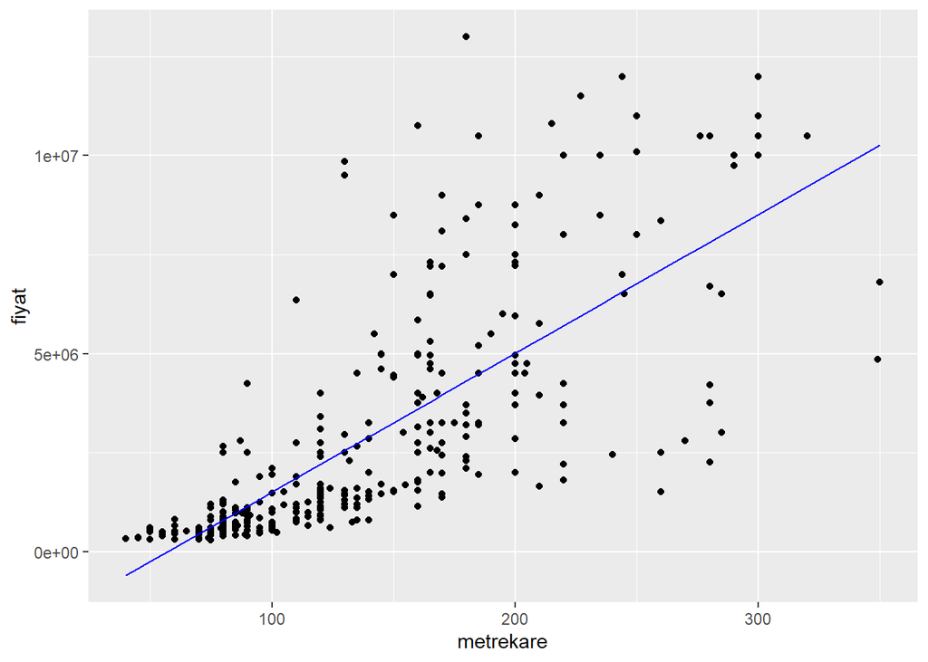

```r
reg0_results %>%
  ggplot(mapping = aes(x = metrekare)) +
  geom_point(mapping = aes(y = `fiyat`)) +
  geom_line(mapping = aes(y = .fitted), color = "blue")
```

Kalıntıların ve fit değerlerinin çizimi:

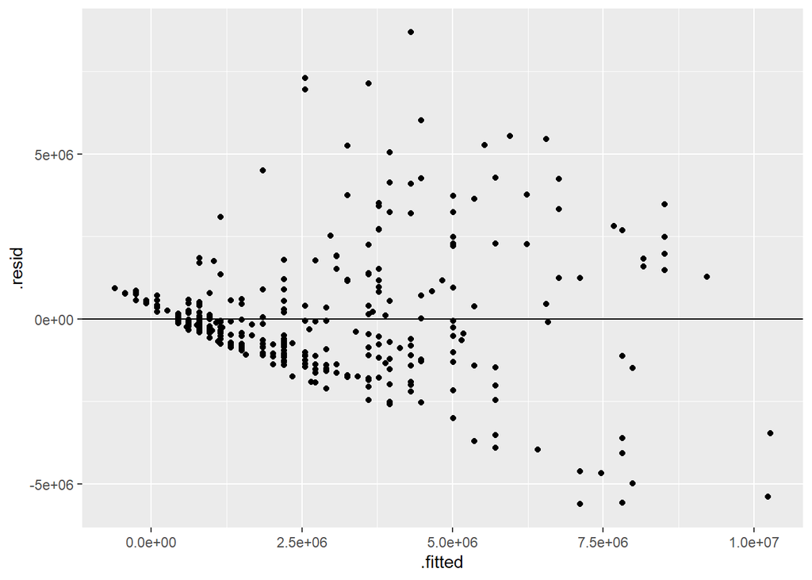

```r
reg0_results %>%
  ggplot(aes(x = .fitted, y = .resid)) +
  geom_point() +
  geom_hline(yintercept = 0)
```

Kalıntılar 0 çevresinde rassal dağılmıyor. Belirgin bir şekilde $\hat{fiyat}$ artarken kalıntıların değerler de mutlak olarak artıyor (aralık genişliyor). Buna benzer örüntü genellikle doğrusal olmayan ilişkilerin varlığına veya değişen varyans problemine işaret edebilir.

Base R’daki plot fonksiyonu ile de diagnostik grafikleri otomatik olarak çizmek mümkündür:

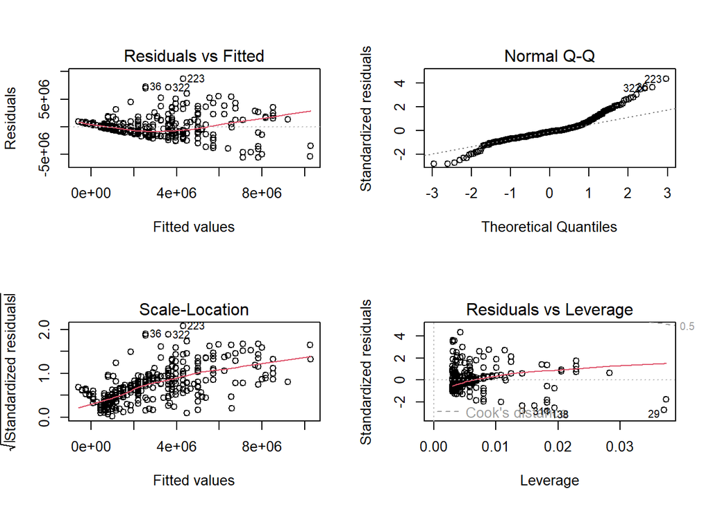

```r
par(mfrow=c(2,2))
plot(reg0)
```

Bu grafikleri sırayla çizelim:

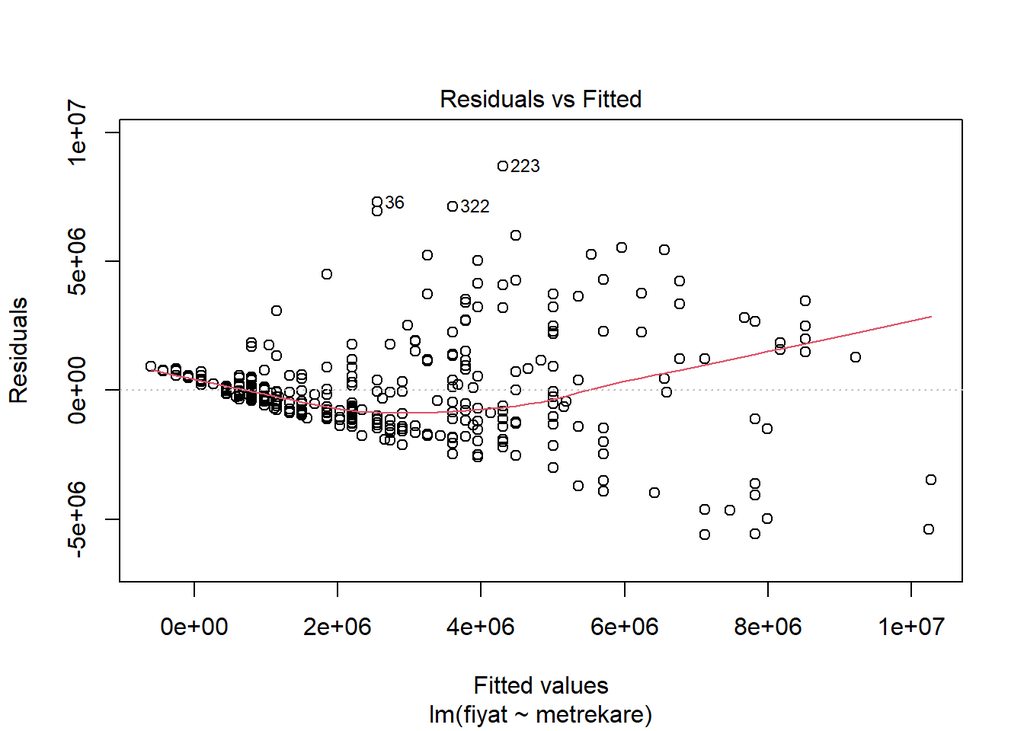

```r
plot(reg0, which = 1)
```

- **Residuals vs Fitted**: Sol üstteki ilk grafikte daha önce çizdiğimiz residual-fitted serpilme çizimini görüyoruz. Doğrusal olmayan ilişkilerin varlığına işaret ediyordu.

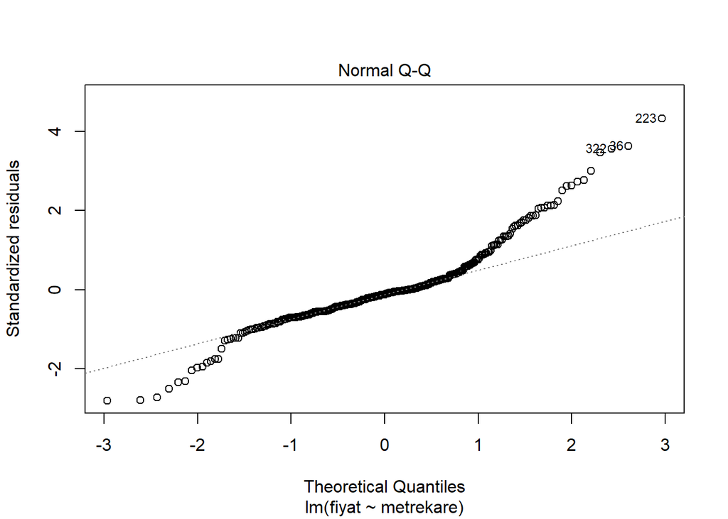

```r
plot(reg0, which = 2)
```

- **Normal Q-Q**: İkinci grafik normal dağılımdan sapmaları gösteren Q-Q grafiğidir. Standardize edilmiş kalıntılar eğer normal dağılırsa aşağı yukarı kesikli çizgi ile çakışmalıdır. Ancak özellikle kuyruklarda normallikten bazı sapmaların olduğunu görüyoruz. Daha fazla kanıt için normallik testleri yapılabilir.

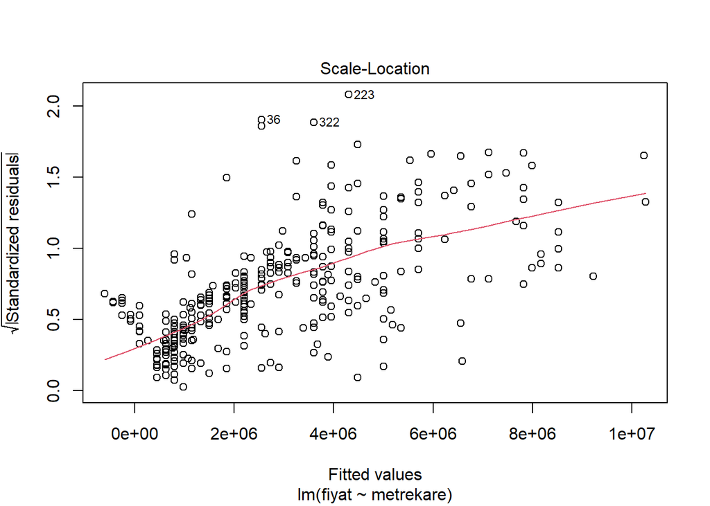

```r
plot(reg0, which = 3)
```

- **Scale-Location**: Üçüncü grafik (alt sol) kalıntı ve fit değerlerinin scale-location grafiğini görüyoruz. Dikey eksende standardize edilmiş kalıntıların mutlak değerinin kare kökü yer alıyor. Yine bu grafikte de sıfır çevresinde rassal bir dağılım bekliyoruz. Eğer belirgin bir örüntü varsa bu kalıntıların varyansının sabit olmadığına işaret eder (heteroskedasticity). Ancak bu grafiğin yorumunu fonksiyon kalıbını doğru bir şekilde seçtiğimizden emin olarak yapmalıyız.

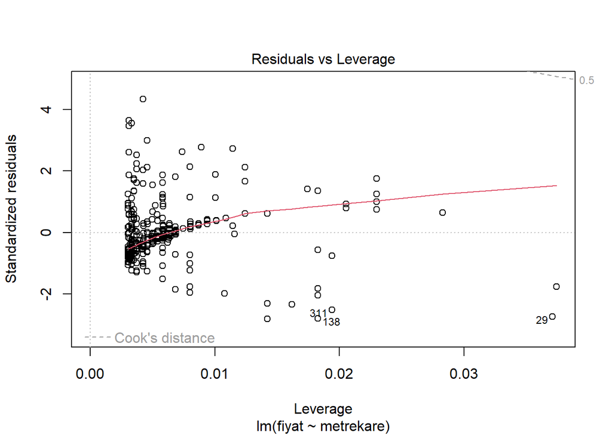

```r
plot(reg0, which = 5)
```

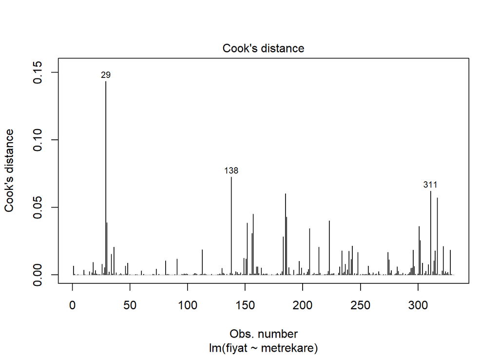

```r
plot(reg0, which = 4)
```

```r
# 0.1'den daha büyük Cook's D değeri hangi gözlem:
besiktas_ev[which(cooks.distance(reg0)>0.1),]
```

```
## # A tibble: 1 × 8
##   semt    fiyat metrekare   oda bina_yas  kat        toplam_kat isitma_sistemi
##   <fct>   <dbl>     <dbl> <int> <fct>     <fct>      <fct>      <fct>
## 1 Ulus  4850000       349     7 1-5 arası Bahçe katı 4          Klima
```

Modeli log-level formunda tahmin edelim:

```r
reg1 <- lm(log(fiyat) ~ metrekare, data = besiktas_ev)
summary(reg1)
```

```
##
## Call:
## lm(formula = log(fiyat) ~ metrekare, data = besiktas_ev)
##
## Residuals:
##      Min       1Q   Median       3Q      Max
## -1.71714 -0.38236 -0.08323  0.35049  1.83827
##
## Coefficients:
##              Estimate Std. Error t value Pr(>|t|)
## (Intercept) 1.259e+01  8.114e-02  155.19   <2e-16 ***
## metrekare   1.287e-02  5.288e-04   24.34   <2e-16 ***
## ---
## Signif. codes:  0 '***' 0.001 '**' 0.01 '*' 0.05 '.' 0.1 ' ' 1
##
## Residual standard error: 0.5981 on 329 degrees of freedom
## Multiple R-squared:  0.643,  Adjusted R-squared:  0.6419
## F-statistic: 592.5 on 1 and 329 DF,  p-value: < 2.2e-16
```

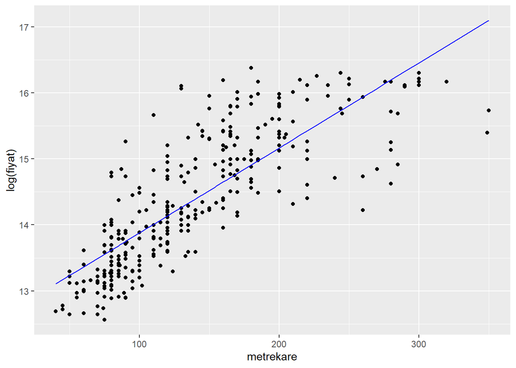

```r
broom::augment(reg1) %>%
  ggplot(mapping = aes(x = metrekare)) +
  geom_point(mapping = aes(y = `log(fiyat)`)) +
  geom_line(mapping = aes(y = .fitted), color = "blue")
```

Kalıntıların ve fit değerlerinin çizimi:

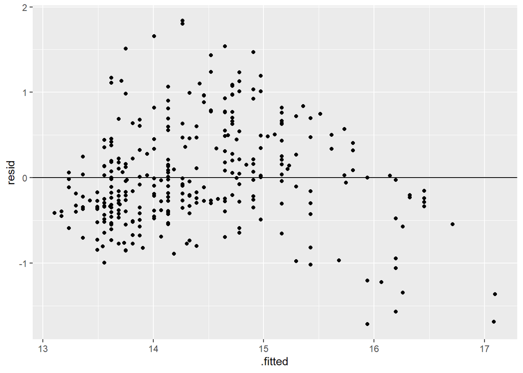

```r
broom::augment(reg1)  %>%
  mutate(resid = `log(fiyat)` - `.fitted`) %>%
  ggplot(aes(x = .fitted, y = resid)) +
  geom_point() +
  geom_hline(yintercept = 0)
```

Kalıntılar ile tahmin değerleri arasında önce artan sonra azalan bir ilişki var. Orijin çevresinde rassal dağılmıyor.

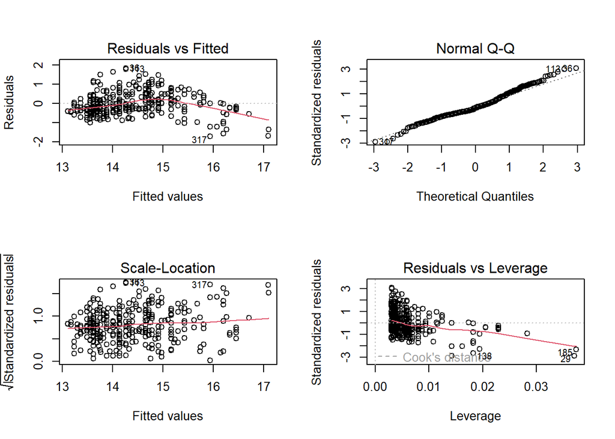

```r
par(mfrow=c(2,2))
plot(reg1)
```

Modele karesel terim ekleyelim:

```r
reg2 <- lm(log(fiyat) ~ metrekare + I(metrekare^2), data = besiktas_ev)
summary(reg2)
```

```
##
## Call:
## lm(formula = log(fiyat) ~ metrekare + I(metrekare^2), data = besiktas_ev)
##
## Residuals:
##      Min       1Q   Median       3Q      Max
## -1.52002 -0.39057 -0.04473  0.36096  1.67384
##
## Coefficients:
##                  Estimate Std. Error t value Pr(>|t|)
## (Intercept)     1.137e+01  1.611e-01  70.596  < 2e-16 ***
## metrekare       3.020e-02  2.097e-03  14.405  < 2e-16 ***
## I(metrekare^2) -5.157e-05  6.074e-06  -8.491 7.23e-16 ***
## ---
## Signif. codes:  0 '***' 0.001 '**' 0.01 '*' 0.05 '.' 0.1 ' ' 1
##
## Residual standard error: 0.5423 on 328 degrees of freedom
## Multiple R-squared:  0.7073, Adjusted R-squared:  0.7055
## F-statistic: 396.3 on 2 and 328 DF,  p-value: < 2.2e-16
```

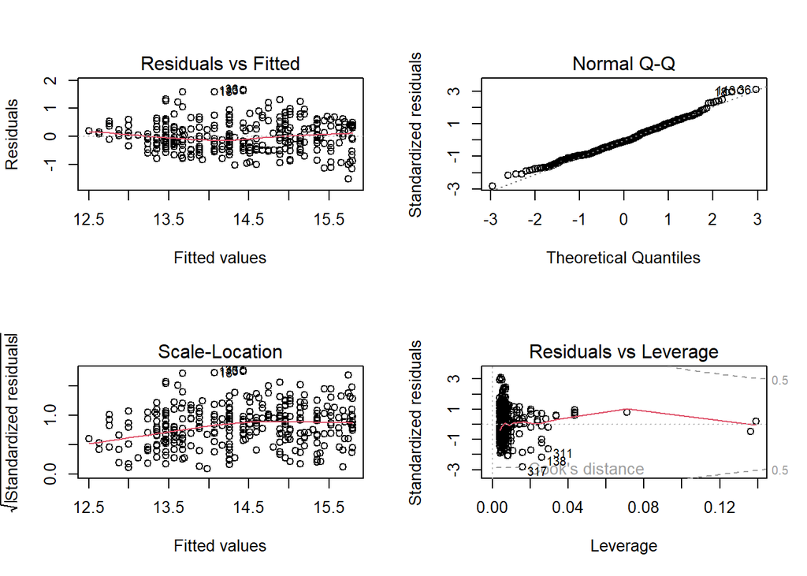

```r
par(mfrow=c(2,2))
plot(reg2)
```

**Örnek**: Simülasyonla bir veri seti türeterek regresyon modeli tahmin edelim ve tanısal grafikleri çizelim.

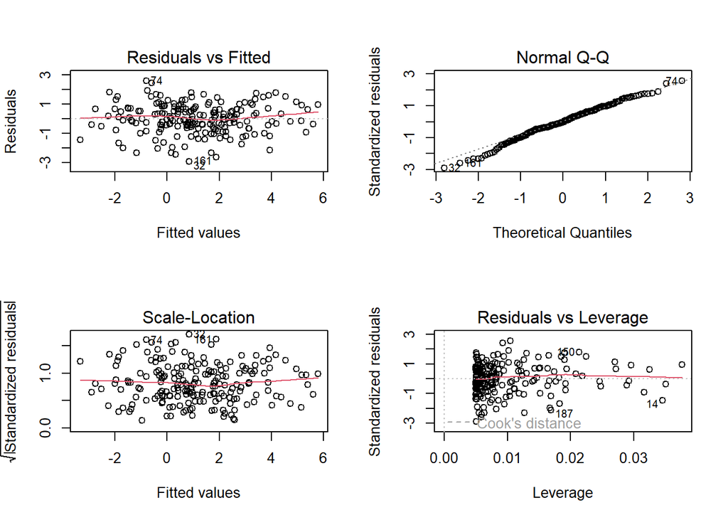

```r
set.seed(1) # aynı sonuçları elde etmek için
n   <- 200
x1  <- rnorm(n, mean=0, sd=1)
y   <- 1 + 2*x1 + rnorm(n, mean=0, sd=1)  # popülasyon regresyon modeli biliniyor
df1 <- tibble(id=1:n, y, x1)
reg_df1 <- lm(y ~ x1, data = df1)
# diagnostic plots
par(mfrow=c(2,2))
plot(reg_df1)
```

`ggplot` ile alternatif tanısal grafikler:

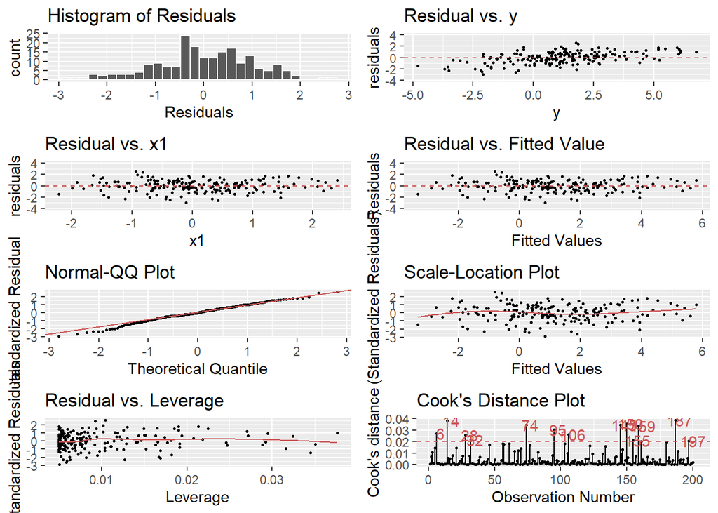

```r
# lindia paketi yüklenmeli
library(lindia)
reg_df1 %>% gg_diagnose(plot.all=TRUE)
```

Residuals-vs-fitted plot:

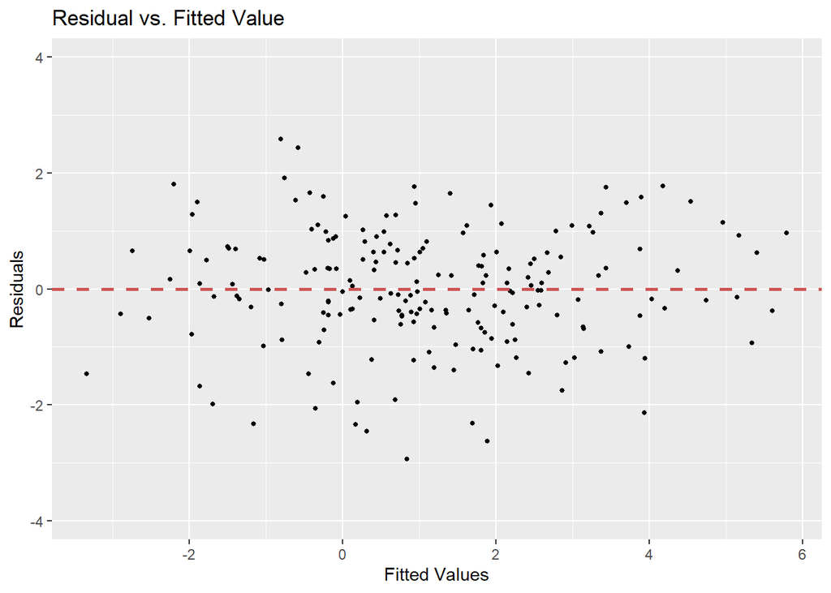

```r
gg_resfitted(reg_df1)
```

**Örnek**: Yüksek etkili gözlemler

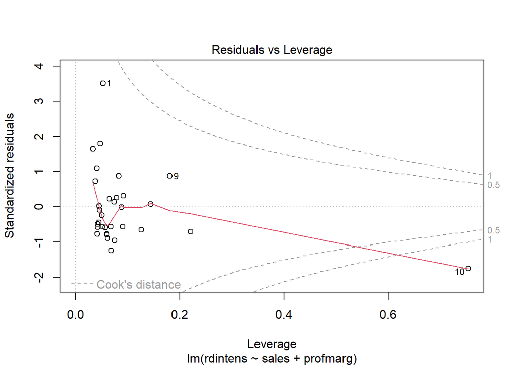

```r
library(wooldridge)
data("rdchem")
# R&D harcamalarının satış ve karlılık üzerine regresyonu
#
plot(lm(rdintens ~ sales + profmarg, data = rdchem), 5)
```

10 numaralı gözlem yüksek etkilidir. Bazı durumlarda log almak bu etkiyi azaltabilir. Örneğin:

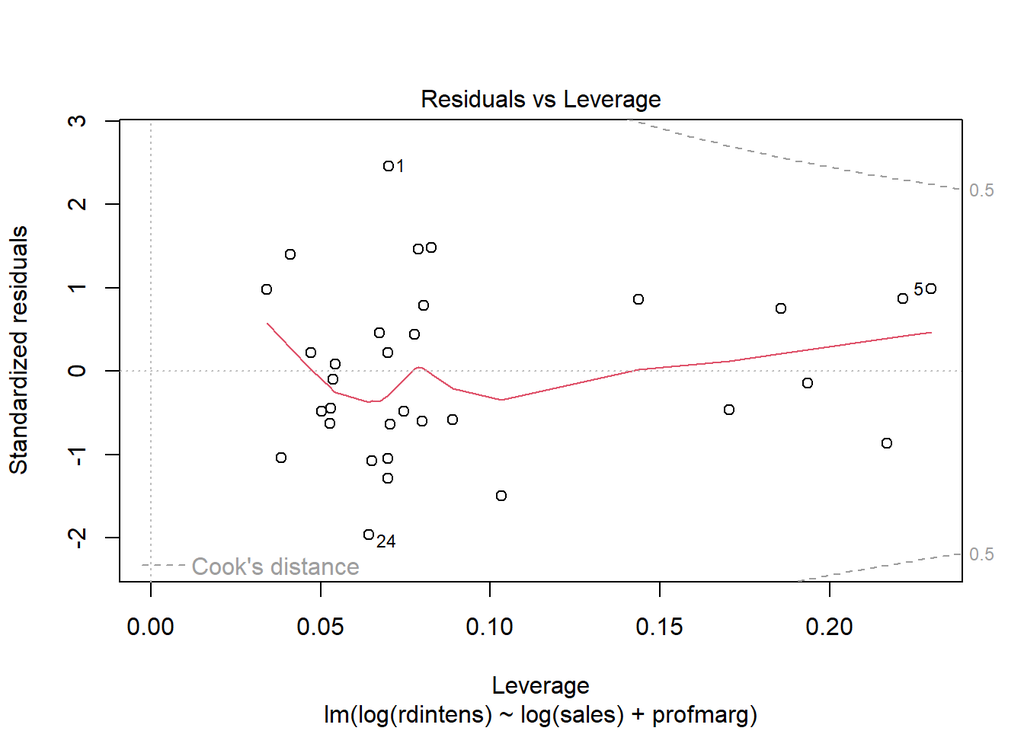

```r
# R&D harcamalarının satış ve karlılık üzerine regresyonu
# log-log kalıbı,
plot(lm(log(rdintens) ~ log(sales) + profmarg, data = rdchem), 5)
```

# 4 Kestirim

OLS ile regresyon modelini tahmin ettikten sonra kestirim yapmak istediğimiz x değerlerini yerine koyarak tahmin değerini hesaplayabiliriz.

## 4.1 Nokta kestirimi

`R`’da `lm()` fonksiyonu ile regresyon nesnesini oluşturduktan sonra `predict()` fonksiyonunu kullanarak kestirim değerlerini ve standart hatalarını hesaplayabiliriz. Örneğin üniversite öğrencilerinin başarısına ilişkin aşağıdaki modeli düşünelim.

```r
data(gpa2, package='wooldridge')
# değişken tanımları için bkz. ?gpa2
# Modelin tahmin edilmesi:
gpa_reg <- lm(colgpa ~ sat + hsperc + hsize + I(hsize^2), data = gpa2)
summary(gpa_reg)
```

```
##
## Call:
## lm(formula = colgpa ~ sat + hsperc + hsize + I(hsize^2), data = gpa2)
##
## Residuals:
##      Min       1Q   Median       3Q      Max
## -2.57543 -0.35081  0.03342  0.39945  1.81683
##
## Coefficients:
##               Estimate Std. Error t value Pr(>|t|)
## (Intercept)  1.493e+00  7.534e-02  19.812  < 2e-16 ***
## sat          1.492e-03  6.521e-05  22.886  < 2e-16 ***
## hsperc      -1.386e-02  5.610e-04 -24.698  < 2e-16 ***
## hsize       -6.088e-02  1.650e-02  -3.690 0.000228 ***
## I(hsize^2)   5.460e-03  2.270e-03   2.406 0.016191 *
## ---
## Signif. codes:  0 '***' 0.001 '**' 0.01 '*' 0.05 '.' 0.1 ' ' 1
##
## Residual standard error: 0.5599 on 4132 degrees of freedom
## Multiple R-squared:  0.2781, Adjusted R-squared:  0.2774
## F-statistic:   398 on 4 and 4132 DF,  p-value: < 2.2e-16
```

```r
# Spesifik x değerlerinin yer aldığı bir data.frame oluşturulması
cvalues <- data.frame(sat = 1200, hsperc=30, hsize=5)
cvalues
```

```
##    sat hsperc hsize
## 1 1200     30     5
```

```r
# Kestirim değeri
predict(gpa_reg, cvalues)
```

```
##        1
## 2.700075
```

```r
# % 95 güven aralığı
predict(gpa_reg, cvalues, interval = "confidence")
```

```
##        fit      lwr      upr
## 1 2.700075 2.661104 2.739047
```

Farklı x değerleri tanımlayalım:

```r
# Define three sets of regressor variables
cvalues <- data.frame(sat = c(1200, 900, 1400),
                      hsperc = c(30, 20, 5),
                      hsize = c(5, 3, 1)
                      )
cvalues
```

```
##    sat hsperc hsize
## 1 1200     30     5
## 2  900     20     3
## 3 1400      5     1
```

```r
# Point estimates and 99% confidence intervals for these
predict(gpa_reg, cvalues, interval = "confidence", level=0.99)
```

```
##        fit      lwr      upr
## 1 2.700075 2.648850 2.751301
## 2 2.425282 2.388540 2.462025
## 3 3.457448 3.385572 3.529325
```

## 4.2 Aralık kestirimi

Güven aralığı bağımlı değişkenin beklenen değerinin tahminine (kestirimi) ilişkin belirsizliği yansıtır. Eğer spesifik bir bireyin üniversitedeki not ortalamasını (GPA) tahmin etmek istersek bu bireye ilişkin belirsizliği yansıtan hata terimini de dikkate almalıyız. R’da `predict()` fonksiyonunda yer alan opsiyonları kullanarak bu kestirimlere ilişkin standart hataları hesaplayabiliriz. Bir gözlem için kestirim yapmak istiyorsak **interval=“prediction”** opsiyonunu, ortalama için kestirim yapmak istiyorsak **interval=“confidence”** opsiyonunu kullanabiliriz.

```r
# nokta kestirimleri ve %95 güven aralığı
predict(gpa_reg, cvalues, interval = "prediction")
```

```
##        fit      lwr      upr
## 1 2.700075 1.601749 3.798402
## 2 2.425282 1.327292 3.523273
## 3 3.457448 2.358452 4.556444
```

Bireysel kestirimlerin güven aralığı çok daha geniştir. Bunun nedeni standart hata hesaplanmasında $\sigma$’nın da dikkate alınmasıdır.

```r
# Ortalama için kestirimler
predict(gpa_reg, cvalues, interval = "confidence")
```

```
##        fit      lwr      upr
## 1 2.700075 2.661104 2.739047
## 2 2.425282 2.397329 2.453235
## 3 3.457448 3.402766 3.512130
```

Pratikte kestirimler oluşturulurken verilerde yer almayan değerlerin kullanılmasından kaçınmak gerekir.

# 5 Regresyon Problemleri ve Makine Öğrenmesi

## 5.1 Geçerleme Kümesi Yaklaşımı

`auto` veri kümesinden hareketle aşağıdaki modeli tahmin etmek istiyoruz:
$$mpg = \beta_0 + \beta_1
horsepower + \epsilon$$

Eğitim veri kümesini rassal olarak belirliyoruz:

```r
library(ISLR)
# rassal sayı üretecinin başlangıç değeri:
set.seed(1)
# eğitim verileri (gözlem numaraları)
# sample() ile n=392 içinden yerine koymadan 196 sayı çekiyoruz:
train <- sample(392, 196)
```

```r
# modeli sadece eğitim verileriyle tahmin et:
lmfit <- lm(mpg ~ horsepower,
            data = Auto,
            subset = train # bu alt kümeyi kullan
            )
lmfit
```

```
##
## Call:
## lm(formula = mpg ~ horsepower, data = Auto, subset = train)
##
## Coefficients:
## (Intercept)   horsepower
##     41.2835      -0.1697
```

Modelimizi `lmfit` nesnesine kaydettik. Şimdi sadece test verileriyle kestirimleri oluşturalım:

```r
# eğitim ve test verilerini oluştur
train_auto <- Auto[train,]
test_auto <- Auto[-train,]
```

```r
# eğitim verilerindeki kestirim
train_predict <- predict(lmfit, train_auto)
# Test veri setinde kestirimleri hesapla
test_predict <- predict(lmfit, test_auto)
```

```r
# Test kestirim hatasını hesapla
test_error <- test_auto$mpg - test_predict
# Ortalama hata karesi (MSE)
mean(test_error^2)
```

```
## [1] 23.26601
```

```r
#
# sadece tek satırda yapmak istersek:
# mean((Auto$mpg-predict(lmfit,Auto))[-train]^2)
```

Alternatif olarak karesel ve kübik modelleri düşünelim:
$$mpg = \beta_0 + \beta_1 horsepower+ \beta_2
horsepower^2 + \epsilon$$

$$mpg = \beta_0 + \beta_1 horsepower+
\beta_2 horsepower^2 + \beta_3 horsepower^3+ \epsilon$$

Karesel model için MSE:

```r
lm.fit2 <- lm(mpg ~ poly(horsepower,2), data = Auto, subset = train)
mean((Auto$mpg-predict(lm.fit2,Auto))[-train]^2)
```

```
## [1] 18.71646
```

Kübik model için MSE:

```r
lm.fit3 <- lm(mpg ~ poly(horsepower,3), data = Auto, subset = train)
mean((Auto$mpg-predict(lm.fit3,Auto))[-train]^2)
```

```
## [1] 18.79401
```

Bu sonuçlara göre en düşük test kestirim hatasını veren model karesel modeldir. Acaba sonuçlar geçerleme kümesine ne kadar duyarlı?

Yeni bir geçerleme veri kümesi oluşturup test MSE hesaplayalım:

```r
set.seed(2)
train <- sample(392, 196)
lm.fit <- lm(mpg ~ horsepower, data = Auto, subset = train)
mean((Auto$mpg-predict(lm.fit,Auto))[-train]^2)
```

```
## [1] 25.72651
```

Karesel model:

```r
lm.fit2 <- lm(mpg ~ poly(horsepower,2), data = Auto, subset = train)
mean((Auto$mpg-predict(lm.fit2,Auto))[-train]^2)
```

```
## [1] 20.43036
```

Kübik model:

```r
lm.fit3 <- lm(mpg ~ poly(horsepower,3), data = Auto, subset = train)
mean((Auto$mpg-predict(lm.fit3,Auto))[-train]^2)
```

```
## [1] 20.38533
```

## 5.2 Biri-Hariç Çapraz Geçerleme (LOOCV)

Biri-hariç çapraz geçerlemede (LOOCV - Leave-one-out Cross Validation) modeli bir gözlemi dışarıda bırakarak tahmin ediyoruz. Dışarıda bırakılan gözlemi kestirim yapmak için kullanıyoruz. Bunun için `boot` paketindeki `cv.glm()` fonksiyonunu `glm()` ile birlikte kullanabiliriz.

`glm()` fonksiyonu `lm()`’e benzer:

```r
# modeli glm ile tahmin et:
glm.fit <- glm(mpg ~ horsepower, data = Auto)
coef(glm.fit)
```

```
## (Intercept)  horsepower
##  39.9358610  -0.1578447
```

```r
# lm ile tahmin:
lm.fit <- lm(mpg ~ horsepower, data = Auto)
coef(lm.fit)
```

```
## (Intercept)  horsepower
##  39.9358610  -0.1578447
```

`cv.glm()` fonksiyonunun kullanımı:

```r
library(boot)
glm.fit <- glm(mpg ~ horsepower, data = Auto)
cv.err <- cv.glm(Auto, glm.fit)
cv.err$delta
```

```
## [1] 24.23151 24.23114
```

`cv.err$delta` çapraz geçerleme ortalama hatasını vermektedir (ilk değer LOOCV kestirim hatası, ikinci değer ise düzeltilmiş kestirim hatasıdır). `cv.glm()` default olarak LOOCV uygular. K-katlı çapraz geçerleme için de kullanılabilir.

LOOCV yaklaşımını biraz daha karmaşık modellere uygulayalım ve sonuçları karşılaştıralım. Beşinci dereceye kadar polinom modeller tahmin edeceğiz. Bunu bir döngü içinde yapmak daha pratiktir:

```r
# 5 elemanlı sıfır vektörü; döngü içinde güncellenecek
cv.error <- rep(0,5)
#
for (i in 1:5){
  glm.fit <- glm(mpg ~ poly(horsepower,i), data = Auto)
  cv.error[i] <- cv.glm(Auto, glm.fit)$delta[1]
}
cv.error
```

```
## [1] 24.23151 19.24821 19.33498 19.42443 19.03321
```

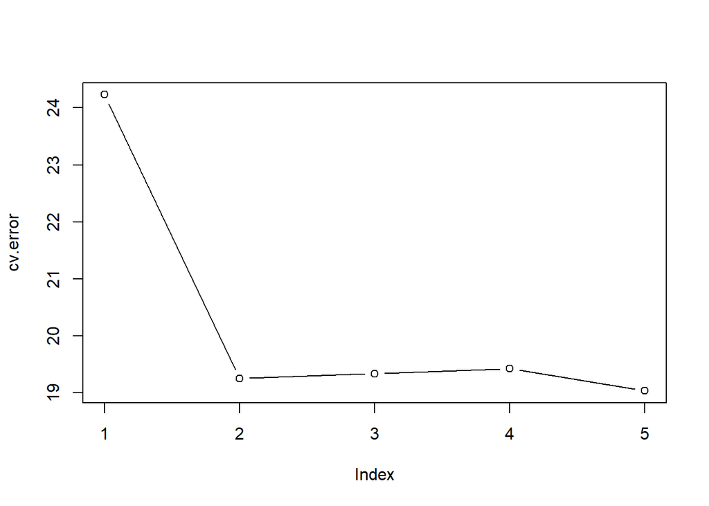

```r
plot(cv.error, type = "b")
```

## 5.3 $k$-katlı Çapraz Geçerleme

Bunun için `cv.glm()` fonksiyonunu kullanabiliriz. Örneğin, $k=10$ için doğrusal modelde çapraz geçerleme test hatası:

```r
set.seed(12345)
glm.fit <- glm(mpg ~ horsepower, data = Auto)
cv_lin_error_10 <- cv.glm(Auto, glm.fit, K=10)$delta[1]
cv_lin_error_10
```

```
## [1] 24.31806
```

5. dereceye kadar polinom değerler için 10-katlı çapraz geçerleme test hata tahminleri:

```r
# aynı sonuçlar için seed değeri:
set.seed(17)
cv.error.10 <- rep(0,5)
for (i in 1:5){
  glm.fit <- glm(mpg ~ poly(horsepower,i), data = Auto)
  cv.error.10[i] <- cv.glm(Auto, glm.fit, K=10)$delta[1]
}
cv.error.10
```

```
## [1] 24.27207 19.26909 19.34805 19.29496 19.03198
```

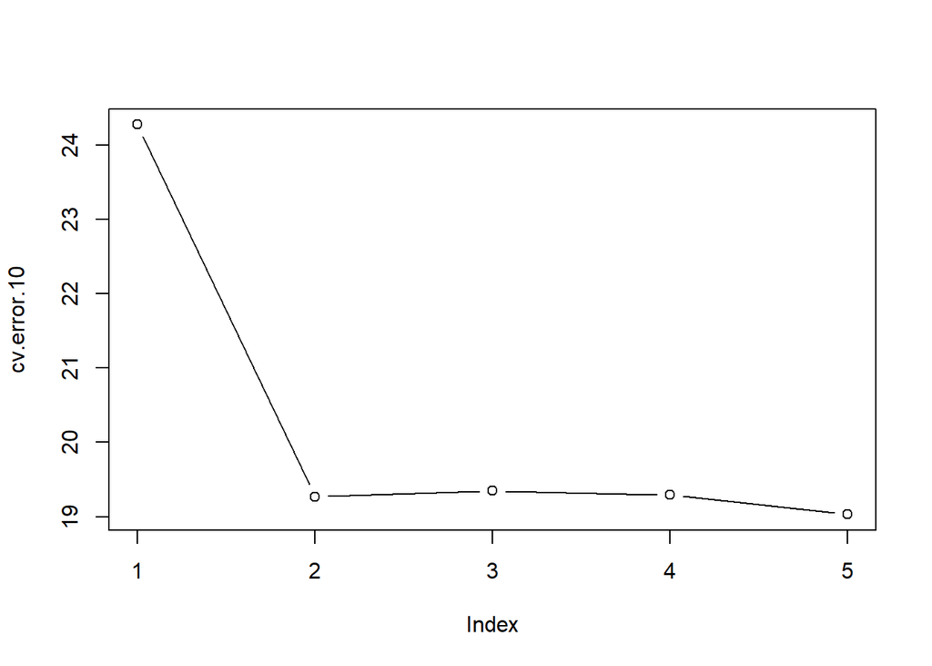

```r
plot(cv.error.10, type = "b")
```